# Analysis of Orphan Wells in Texas

## Data Sources

- **Well Data**: Contains information about wells including their API number, operator, lease name, completion date, and plug date.
- **Well Shapes**: Geospatial data of wells.
- **Orphaned Wells Shape**: Contains information about orphaned wells including a unique identifier (`well_ident`).
- **Inspections**: Contains details about inspections including `inspection_date`, `operator_name`, `district`, and `district_office_inspecting`.
- **Violations**: Contains details about violations including `violation_disc_date`.
- **Well Inspections**: Maps wells to their inspections.
- **Well Violations**: Maps wells to their violations.

## Key Steps and Analysis

### 1. Data Preparation

- **Standardized API Numbers**: Extracted 8-digit API numbers from the `well_ident` field in the orphaned wells dataset.
- **Merged Data**: Combined well data with shapes and orphaned wells data to create a detailed dataset of orphan wells.
- **Filtered Data**: Separated the dataset into plugged and unplugged wells for focused analysis.

### 2. Inspection and Violation Data

- **Merged Inspection and Violation Data**: Incorporated inspection and violation dates into the orphan wells dataset.
- **Handled Missing/Invalid Dates**: Cleaned the data to ensure valid dates for meaningful analysis.

### 3. Visualization

- **Distribution of Plugged and Unplugged Wells**: Created maps to visualize the spatial distribution of plugged and unplugged orphan wells in Texas.
- **Inspection and Violation Analysis**: Analyzed the most recent inspection and violation dates, and visualized the data by district and district office.

## Summary of Findings

### Spatial Distribution

- **Plugged Wells**: A small number of orphan wells have been plugged.
- **Unplugged Wells**: A significant number of orphan wells remain unplugged.

### Inspection and Violation History

- **Inspection Dates**: The distribution of the most recent inspection dates varies across different districts and district offices, with some areas showing more recent activity.
- **Violation Dates**: The distribution of violation dates also varies, highlighting areas where regulatory enforcement may be more active.

```python
import pandas as pd
import geopandas as gpd
from sqlalchemy import create_engine, text
import os
from shapely.geometry import Point


# Get environment variables for PostgreSQL connection
db_user = os.environ.get('DB_USER')
db_password = os.environ.get('DB_PASSWORD')
db_host = os.environ.get('DB_HOST')
db_port = os.environ.get('DB_PORT')

if not all([db_user, db_password, db_host, db_port]):
    raise ValueError("Missing required environment variables")

# Create a connection to the PostgreSQL database
engine = create_engine(f'postgresql://{db_user}:{db_password}@{db_host}:{db_port}/texas_oil')

# Load the datasets
well_data = pd.read_sql("SELECT * FROM well_data", engine)
well_shapes = gpd.read_postgis("SELECT * FROM well_shapes", engine, geom_col='geometry')
orphaned_wells_shape = gpd.read_postgis("SELECT * FROM orphaned_wells_shape", engine, geom_col='geom')
```

```python
# Extract the 8-digit API number from well_ident in orphaned_wells_shape
orphaned_wells_shape['api_no'] = orphaned_wells_shape['well_ident'].str[9:17]

# Confirm the changes
print(orphaned_wells_shape['api_no'].str.len().value_counts())
```

```
api_no
8    5854
Name: count, dtype: int64
```

```python
# Merge well_data with well_shapes
well_data_merged = well_data.merge(well_shapes, left_on='api_num', right_on='api', how='left')

# Merge orphaned wells with well data
orphan_wells_detailed = orphaned_wells_shape.merge(well_data_merged, left_on='api_no', right_on='api_num', how='left')

# Check the number of rows in the merged dataset
print(f"Number of rows in orphan_wells_detailed: {orphan_wells_detailed.shape[0]}")
```

```
Number of rows in orphan_wells_detailed: 5854
```

```python
# Filter for plugged and unplugged orphan wells and make explicit copies
plugged_wells = orphan_wells_detailed[~orphan_wells_detailed['plug_date'].isna()].copy()
unplugged_wells = orphan_wells_detailed[orphan_wells_detailed['plug_date'].isna()].copy()

# Confirm the shapes of the DataFrames
print(f"Plugged wells: {plugged_wells.shape}")
print(f"Unplugged wells: {unplugged_wells.shape}")
```

```
Plugged wells: (42, 50)
Unplugged wells: (5812, 50)
```

```python
from shapely.geometry import Point

# Ensure the geometry is of type Point
plugged_wells['geometry'] = plugged_wells['geom'].apply(lambda geom: Point(geom) if not isinstance(geom, Point) else geom)
unplugged_wells['geometry'] = unplugged_wells['geom'].apply(lambda geom: Point(geom) if not isinstance(geom, Point) else geom)

# Confirm the conversion
print(plugged_wells['geometry'].head())
print(unplugged_wells['geometry'].head())
```

```
72     POINT (-97.08083 28.12263)
73     POINT (-97.08487 28.11898)
117    POINT (-98.77794 33.49511)
121    POINT (-98.66392 33.42920)
132    POINT (-98.62661 33.77864)
Name: geometry, dtype: geometry
0    POINT (-95.45665 31.80250)
1    POINT (-95.45862 31.80158)
2    POINT (-95.71999 31.95961)
3    POINT (-95.48025 31.62255)
4    POINT (-95.48040 31.62388)
Name: geometry, dtype: geometry
```

```python
# Ensure api_no columns are strings of 8 digits
plugged_wells['api_no'] = plugged_wells['api_no'].astype(str).str.zfill(8)
unplugged_wells['api_no'] = unplugged_wells['api_no'].astype(str).str.zfill(8)
```

```python
from sqlalchemy import text

# Create SQL commands to create the tables
create_plugged_wells_table = """
CREATE TABLE IF NOT EXISTS plugged_orphan_wells (
    id SERIAL PRIMARY KEY,
    api_no VARCHAR(8),
    plug_date DATE,
    geometry GEOMETRY(Point, 4326),
    operator VARCHAR,
    lease_name VARCHAR,
    completion_date DATE
);
"""

create_unplugged_wells_table = """
CREATE TABLE IF NOT EXISTS unplugged_orphan_wells (
    id SERIAL PRIMARY KEY,
    api_no VARCHAR(8),
    plug_date DATE,
    geometry GEOMETRY(Point, 4326),
    operator VARCHAR,
    lease_name VARCHAR,
    completion_date DATE
);
"""

# Execute the SQL commands
with engine.connect() as conn:
    conn.execute(text(create_plugged_wells_table))
    conn.execute(text(create_unplugged_wells_table))

# Write the DataFrames to the PostgreSQL database
plugged_wells.to_postgis('plugged_orphan_wells', engine, if_exists='replace', index=False)
unplugged_wells.to_postgis('unplugged_orphan_wells', engine, if_exists='replace', index=False)

print("Data inserted into PostgreSQL tables successfully.")
```

```
Data inserted into PostgreSQL tables successfully.
```

```python
# Check if the data has been correctly inserted into the plugged_orphan_wells table
plugged_wells_in_db = gpd.read_postgis("SELECT * FROM plugged_orphan_wells", engine, geom_col='geom')
print(f"Plugged wells in database: {plugged_wells_in_db.shape}")

# Check if the data has been correctly inserted into the unplugged_orphan_wells table
unplugged_wells_in_db = gpd.read_postgis("SELECT * FROM unplugged_orphan_wells", engine, geom_col='geom')
print(f"Unplugged wells in database: {unplugged_wells_in_db.shape}")
```

```
Plugged wells in database: (42, 50)
Unplugged wells in database: (5812, 50)
```

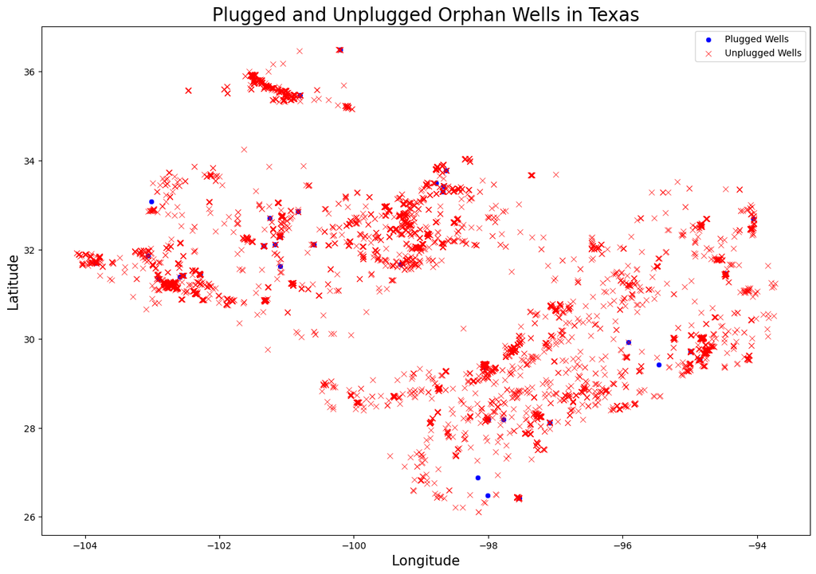

```python
import seaborn as sns

# Plotting the spatial distribution using seaborn for better clarity
plt.figure(figsize=(15, 10))
sns.scatterplot(x=plugged_wells_in_db.geometry.x, y=plugged_wells_in_db.geometry.y, color='blue', marker='o', label='Plugged Wells')
sns.scatterplot(x=unplugged_wells_in_db.geometry.x, y=unplugged_wells_in_db.geometry.y, color='red', marker='x', label='Unplugged Wells')
plt.title('Plugged and Unplugged Orphan Wells in Texas', fontsize=20)
plt.xlabel('Longitude', fontsize=15)
plt.ylabel('Latitude', fontsize=15)
plt.legend()
plt.show()
```

```python
# Basic summary statistics
plugged_wells_summary = plugged_wells.describe()
unplugged_wells_summary = unplugged_wells.describe()

print("Summary Statistics for Plugged Wells:")
print(plugged_wells_summary)

print("\nSummary Statistics for Unplugged Wells:")
print(unplugged_wells_summary)
```

```
Summary Statistics for Plugged Wells:
                 gid  township  range  section_x   total_depth
count      42.000000      42.0   42.0       42.0     42.000000
mean   109569.642857       0.0    0.0        0.0   5373.785714
std      2007.969352       0.0    0.0        0.0   4006.910765
min    106902.000000       0.0    0.0        0.0      0.000000
25%    107825.750000       0.0    0.0        0.0   1537.250000
50%    109284.000000       0.0    0.0        0.0   5079.500000
75%    111544.250000       0.0    0.0        0.0   9400.000000
max    112577.000000       0.0    0.0        0.0  12974.000000

Summary Statistics for Unplugged Wells:
                 gid  township   range  section_x   total_depth
count    5812.000000    5812.0  5812.0     5812.0     92.000000
mean   109757.850310       0.0     0.0        0.0   2758.597826
std      1687.663007       0.0     0.0        0.0   4298.982916
min    106830.000000       0.0     0.0        0.0      0.000000
25%    108298.750000       0.0     0.0        0.0      0.000000
50%    109757.500000       0.0     0.0        0.0      0.000000
75%    111218.250000       0.0     0.0        0.0   5818.500000
max    112683.000000       0.0     0.0        0.0  12159.000000
```

```python
# Distribution of plugged wells by operator
plugged_operator_distribution = plugged_wells['operator'].value_counts()
print("Plugged Wells by Operator:")
print(plugged_operator_distribution)

# Distribution of unplugged wells by operator
unplugged_operator_distribution = unplugged_wells['operator'].value_counts()
print("\nUnplugged Wells by Operator:")
print(unplugged_operator_distribution)
```

```
Plugged Wells by Operator:
operator
LODI DRILLING & SERVICE CO.         3
DIAMONDBACK E&P LLC                 3
CHITTIM OPERATING LLC               2
TRIUM, LTD.                         2
GREAT PLAINS RESOURCES, INC.        2
PIONEER NATURAL RES. USA, INC.      2
ENDEAVOR ENERGY RESOURCES L.P.      1
OXY USA INC.                        1
HANLEY PETROLEUM INC.               1
CHAMA RESOURCES                     1
CEDAR POINT OIL COMPANY             1
EXXON CORPORATION                   1
OMNI PETROLEUM CORPORATION          1
COBLAN OPERATING COMPANY            1
SOUTHLAND ROYALTY COMPANY           1
COG OPERATING LLC                   1
J & A OIL PROPERTIES                1
R & R ENERGY, LTD.                  1
BRAZOS OIL CO.                      1
XTO ENERGY INC.                     1
MARALO, LLC                         1
SEAY OIL & GAS, LTD.                1
PRIME OPERATING COMPANY             1
OIL PRODUCERS, INC. OF KANSAS       1
CONOCO INC.                         1
                                    1
DINERO OIL CORPORATION              1
SULLIVAN, HOLLIS R. INC.            1
QUINOCO PETROLEUM, INC.             1
EXXON CORP.                         1
TABOR CREEK OIL COMPANY             1
EMBASSY WELL SERVICE, LLC           1
T - C OIL COMPANY                   1
INTERGRATED O & G SOLUTIONS CORP    1
Name: count, dtype: int64

Unplugged Wells by Operator:
operator
```

[output cut: 32 more lines]

```
EXXON MOBIL CORPORATION              1
SUMMIT PETROLEUM LLC                 1
UNION PACIFIC RESOURCES COMPANY      1
WINN OPERATING, LLC                  1
CEMCO OIL                            1
WINDSOR ENERGY GROUP, L.L.C.         1
DOME ENERGY CORPORATION              1
ALPHA TWENTY-ONE PRODUCTION CO.      1
BOAZ ENERGY II OPERATING, LLC        1
DOYAL, MELVIN BAXTER                 1
EXPLORER ENERGY CORP.                1
RUTLEDGE, ROY                        1
SABINAL ENERGY OPERATING, LLC        1
BROOKSTON ENERGY, INC.               1
Name: count, dtype: int64
```

```python
# Load the datasets
well_inspections = pd.read_sql("SELECT * FROM well_inspections", engine)
well_violations = pd.read_sql("SELECT * FROM well_violations", engine)
inspections = pd.read_sql("SELECT * FROM inspections", engine)
violations = pd.read_sql("SELECT * FROM violations", engine)
```

```python
# Standardize API numbers in well_inspections and well_violations
well_inspections['api_well_id'] = well_inspections['api_well_id'].astype(str).str.zfill(8)
well_violations['api_well_id'] = well_violations['api_well_id'].astype(str).str.zfill(8)
```

```python
# Merge unplugged wells with well_inspections to get inspection IDs
unplugged_wells_with_inspections = unplugged_wells.merge(well_inspections, left_on='api_no', right_on='api_well_id', how='left')

# Merge unplugged wells with well_violations to get violation IDs
unplugged_wells_with_violations = unplugged_wells.merge(well_violations, left_on='api_no', right_on='api_well_id', how='left')

# Merge unplugged_wells_with_inspections with inspections to get inspection dates
unplugged_wells_with_inspection_dates = unplugged_wells_with_inspections.merge(
    inspections[['id', 'inspection_date']],
    left_on='inspection_id', right_on='id', how='left', suffixes=('', '_inspection'))

# Merge unplugged_wells_with_violations with violations to get violation dates
unplugged_wells_with_violation_dates = unplugged_wells_with_violations.merge(
    violations[['id', 'violation_disc_date']],
    left_on='violation_id', right_on='id', how='left', suffixes=('', '_violation'))

# Drop the extra 'id' columns after merge
unplugged_wells_with_inspection_dates.drop(['id'], axis=1, inplace=True)
unplugged_wells_with_violation_dates.drop(['id'], axis=1, inplace=True)
```

```python
# Combine the inspection and violation data
unplugged_wells_full = unplugged_wells_with_inspection_dates.merge(
    unplugged_wells_with_violation_dates, on='api_no', how='outer', suffixes=('', '_violation'))

# Confirm the final DataFrame
print(unplugged_wells_full.columns)
```

```
Index(['gid', 'well_ident', 'state', 'county', 'well_name', 'well_numbe',
       'type', 'status', 'latitude', 'longitude',
       ...
       'on_off_schedule_violation', 'oil_gas_code_violation',
       'filler_2_violation', 'api_violation', 'geometry_violation',
       'properties_violation', 'violation_id', 'api_well_id_violation',
       'id_violation', 'violation_disc_date'],
      dtype='object', length=107)
```

```python
# Group by api_no to find the most recent inspection and violation dates
most_recent_inspections = unplugged_wells_full.groupby('api_no')['inspection_date'].max().reset_index()
most_recent_violations = unplugged_wells_full.groupby('api_no')['violation_disc_date'].max().reset_index()

# Merge the most recent dates back to the unplugged_wells_full DataFrame
unplugged_wells_full = unplugged_wells_full.merge(most_recent_inspections, on='api_no', suffixes=('', '_most_recent_inspection'))
unplugged_wells_full = unplugged_wells_full.merge(most_recent_violations, on='api_no', suffixes=('', '_most_recent_violation'))

# Confirm the final DataFrame
print(unplugged_wells_full[['api_no', 'inspection_date_most_recent_inspection', 'violation_disc_date_most_recent_violation']].head())
```

```
     api_no inspection_date_most_recent_inspection  \
0  00001000                             2019-09-05
1  00003000                             2015-09-02
2  00003000                             2015-09-02
3  00004000                             2019-07-18
4  00004000                             2019-07-18

  violation_disc_date_most_recent_violation
0                                       NaN
1                                       NaN
2                                       NaN
3                                2019-07-18
4                                2019-07-18
```

```python
# Summary statistics for inspection dates of unplugged wells
inspection_date_summary_unplugged = unplugged_wells_full['inspection_date_most_recent_inspection'].describe()
print("Summary Statistics for Most Recent Inspection Dates (Unplugged Wells):")
print(inspection_date_summary_unplugged)

# Summary statistics for violation dates of unplugged wells
violation_date_summary_unplugged = unplugged_wells_full['violation_disc_date_most_recent_violation'].describe()
print("\nSummary Statistics for Most Recent Violation Dates (Unplugged Wells):")
print(violation_date_summary_unplugged)
```

```
Summary Statistics for Most Recent Inspection Dates (Unplugged Wells):
count           1218
unique           147
top       2023-11-20
freq             153
Name: inspection_date_most_recent_inspection, dtype: object

Summary Statistics for Most Recent Violation Dates (Unplugged Wells):
count            526
unique            29
top       2023-08-29
freq             153
Name: violation_disc_date_most_recent_violation, dtype: object
```

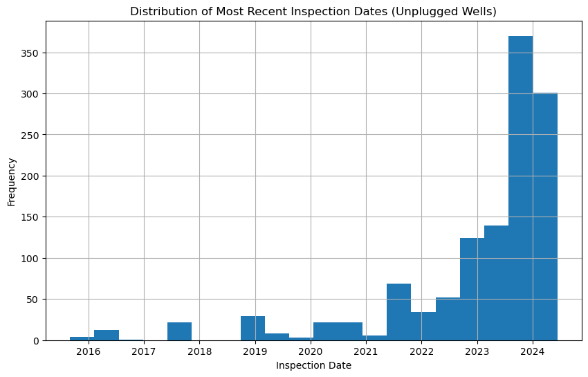

```python
import matplotlib.pyplot as plt

# Plot the distribution of inspection dates for unplugged wells
plt.figure(figsize=(10, 6))
unplugged_wells_full['inspection_date_most_recent_inspection'].dropna().hist(bins=20)
plt.title('Distribution of Most Recent Inspection Dates (Unplugged Wells)')
plt.xlabel('Inspection Date')
plt.ylabel('Frequency')
plt.show()
```

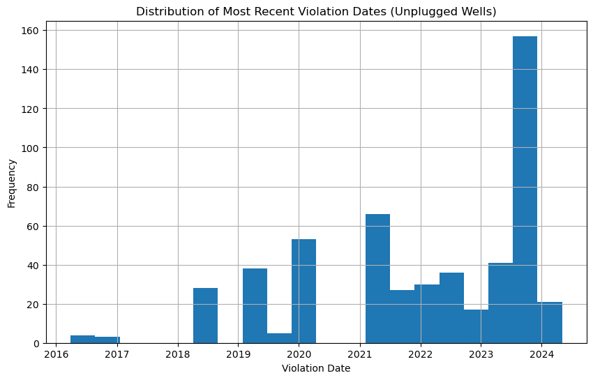

```python
# Plot the distribution of violation dates for unplugged wells
plt.figure(figsize=(10, 6))
unplugged_wells_full['violation_disc_date_most_recent_violation'].dropna().hist(bins=20)
plt.title('Distribution of Most Recent Violation Dates (Unplugged Wells)')
plt.xlabel('Violation Date')
plt.ylabel('Frequency')
plt.show()
```

```python
# Merge unplugged wells with inspections to get operator names
unplugged_wells_with_operator = unplugged_wells_full.merge(
    inspections[['id', 'operator_name']],
    left_on='inspection_id', right_on='id', how='left', suffixes=('', '_inspection'))

# Confirm the final DataFrame
print(unplugged_wells_with_operator[['api_no', 'inspection_date_most_recent_inspection', 'violation_disc_date_most_recent_violation', 'operator_name']].head())
```

```
     api_no inspection_date_most_recent_inspection  \
0  00001000                             2019-09-05
1  00003000                             2015-09-02
2  00003000                             2015-09-02
3  00004000                             2019-07-18
4  00004000                             2019-07-18

  violation_disc_date_most_recent_violation                operator_name
0                                       NaN            JETTA PERMIAN, LP
1                                       NaN      PATRIOT RESOURCES, INC.
2                                       NaN      PATRIOT RESOURCES, INC.
3                                2019-07-18            JETTA PERMIAN, LP
4                                2019-07-18  ARRIS OPERATING COMPANY LLC
```

```python
# Group by operator_name to get summary statistics for inspection dates
inspection_date_by_operator = unplugged_wells_with_operator.groupby('operator_name')['inspection_date_most_recent_inspection'].describe()
print("Summary Statistics for Most Recent Inspection Dates by Operator:")
print(inspection_date_by_operator)

# Group by operator_name to get summary statistics for violation dates
violation_date_by_operator = unplugged_wells_with_operator.groupby('operator_name')['violation_disc_date_most_recent_violation'].describe()
print("\nSummary Statistics for Most Recent Violation Dates by Operator:")
print(violation_date_by_operator)
```

```
Summary Statistics for Most Recent Inspection Dates by Operator:
                              count unique         top freq
operator_name
ACCORD GR ENERGY INC             15      1  2024-03-07   15
ADAMS AFFILIATES, INC.            8      1  2024-03-06    8
AMERICO ENERGY RESOURCES, LLC     4      1  2024-01-03    4
AMPLIFY ENERGY OPERATING LLC      2      1  2023-05-11    2
APACHE CORPORATION               20      6  2024-04-17   12
...                             ...    ...         ...  ...
WTG EXPLORATION                   3      1  2023-04-14    3
XTO ENERGY INC.                  20      6  2024-04-25    8
ZARVONA ENERGY LLC               10      2  2023-04-05    8
ZIVNEY ENERGY                     7      1  2022-03-09    7
ZK PETROLEUM CO., L.L.C.          2      1  2019-04-29    2

[164 rows x 4 columns]

Summary Statistics for Most Recent Violation Dates by Operator:
                              count unique         top freq
operator_name
ACCORD GR ENERGY INC             15      1  2024-03-07   15
ADAMS AFFILIATES, INC.            0      0         NaN  NaN
AMERICO ENERGY RESOURCES, LLC     0      0         NaN  NaN
AMPLIFY ENERGY OPERATING LLC      0      0         NaN  NaN
APACHE CORPORATION                0      0         NaN  NaN
...                             ...    ...         ...  ...
WTG EXPLORATION                   0      0         NaN  NaN
XTO ENERGY INC.                   3      1  2019-10-24    3
ZARVONA ENERGY LLC                0      0         NaN  NaN
ZIVNEY ENERGY                     0      0         NaN  NaN
ZK PETROLEUM CO., L.L.C.          0      0         NaN  NaN

[164 rows x 4 columns]
```

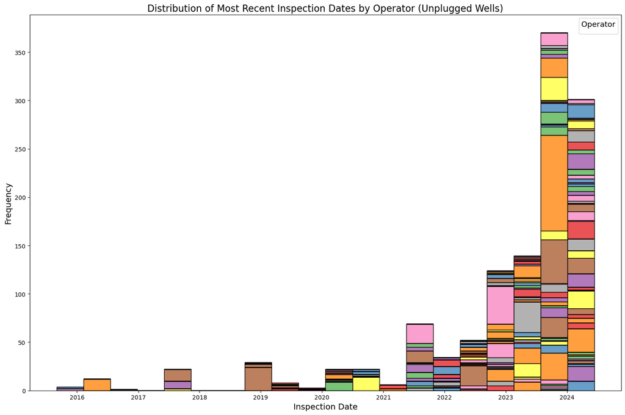

```python
import matplotlib.pyplot as plt
import seaborn as sns
import pandas as pd

# Defragment the DataFrame
unplugged_wells_with_operator = unplugged_wells_with_operator.copy()

# Convert inspection dates to datetime if necessary
if unplugged_wells_with_operator['inspection_date_most_recent_inspection'].dtype != 'datetime64[ns]':
    unplugged_wells_with_operator['inspection_date_most_recent_inspection'] = pd.to_datetime(unplugged_wells_with_operator['inspection_date_most_recent_inspection'])

# Plot the distribution of inspection dates by operator for unplugged wells
plt.figure(figsize=(15, 10))
sns.histplot(data=unplugged_wells_with_operator,
             x='inspection_date_most_recent_inspection',
             hue='operator_name',
             multiple='stack',
             bins=20,
             palette='Set1')

# Title and labels
plt.title('Distribution of Most Recent Inspection Dates by Operator (Unplugged Wells)', fontsize=16)
plt.xlabel('Inspection Date', fontsize=14)
plt.ylabel('Frequency', fontsize=14)

# Customize legend
plt.legend(title='Operator', title_fontsize='13', fontsize='11', loc='upper right')

# Display the plot
plt.tight_layout()
plt.show()
```

```
No artists with labels found to put in legend.  Note that artists whose label start with an underscore are ignored when legend() is called with no argument.
```

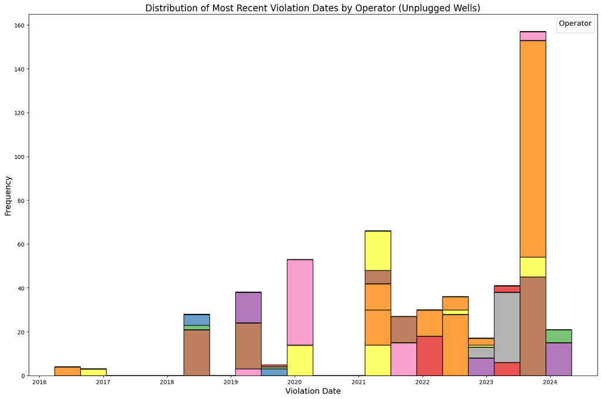

```python
import matplotlib.pyplot as plt
import seaborn as sns
import pandas as pd

# Defragment the DataFrame
unplugged_wells_with_operator = unplugged_wells_with_operator.copy()

# Convert violation dates to datetime if necessary
if unplugged_wells_with_operator['violation_disc_date_most_recent_violation'].dtype != 'datetime64[ns]':
    unplugged_wells_with_operator['violation_disc_date_most_recent_violation'] = pd.to_datetime(unplugged_wells_with_operator['violation_disc_date_most_recent_violation'])

# Plot the distribution of violation dates by operator for unplugged wells
plt.figure(figsize=(15, 10))
sns.histplot(data=unplugged_wells_with_operator,
             x='violation_disc_date_most_recent_violation',
             hue='operator_name',
             multiple='stack',
             bins=20,
             palette='Set1')

# Title and labels
plt.title('Distribution of Most Recent Violation Dates by Operator (Unplugged Wells)', fontsize=16)
plt.xlabel('Violation Date', fontsize=14)
plt.ylabel('Frequency', fontsize=14)

# Customize legend
plt.legend(title='Operator', title_fontsize='13', fontsize='11', loc='upper right')

# Display the plot
plt.tight_layout()
plt.show()
```

```python
# Merge unplugged wells with inspections to get district and district office information
unplugged_wells_with_district = unplugged_wells_full.merge(
    inspections[['id', 'operator_name', 'district', 'district_office_inspecting']],
    left_on='inspection_id', right_on='id', how='left', suffixes=('', '_inspection'))

# Confirm the final DataFrame
print(unplugged_wells_with_district[['api_no', 'inspection_date_most_recent_inspection', 'violation_disc_date_most_recent_violation', 'operator_name', 'district', 'district_office_inspecting']].head())
```

```
     api_no inspection_date_most_recent_inspection  \
0  00001000                             2019-09-05
1  00003000                             2015-09-02
2  00003000                             2015-09-02
3  00004000                             2019-07-18
4  00004000                             2019-07-18

  violation_disc_date_most_recent_violation                operator_name  \
0                                       NaN            JETTA PERMIAN, LP
1                                       NaN      PATRIOT RESOURCES, INC.
2                                       NaN      PATRIOT RESOURCES, INC.
3                                2019-07-18            JETTA PERMIAN, LP
4                                2019-07-18  ARRIS OPERATING COMPANY LLC

  district district_office_inspecting
0       08                    Midland
1       08                    Midland
2       08                    Midland
3       08                    Midland
4       08                    Midland
```

```python
# Group by district to get summary statistics for inspection dates
inspection_date_by_district = unplugged_wells_with_district.groupby('district')['inspection_date_most_recent_inspection'].describe()
print("Summary Statistics for Most Recent Inspection Dates by District:")
print(inspection_date_by_district)

# Group by district office to get summary statistics for inspection dates
inspection_date_by_district_office = unplugged_wells_with_district.groupby('district_office_inspecting')['inspection_date_most_recent_inspection'].describe()
print("\nSummary Statistics for Most Recent Inspection Dates by District Office:")
print(inspection_date_by_district_office)

# Group by district to get summary statistics for violation dates
violation_date_by_district = unplugged_wells_with_district.groupby('district')['violation_disc_date_most_recent_violation'].describe()
print("\nSummary Statistics for Most Recent Violation Dates by District:")
print(violation_date_by_district)

# Group by district office to get summary statistics for violation dates
violation_date_by_district_office = unplugged_wells_with_district.groupby('district_office_inspecting')['violation_disc_date_most_recent_violation'].describe()
print("\nSummary Statistics for Most Recent Violation Dates by District Office:")
print(violation_date_by_district_office)
```

```
Summary Statistics for Most Recent Inspection Dates by District:
         count unique         top freq
district
01         132     13  2023-10-19   44
02          60     11  2022-11-01   15
03          28      8  2022-01-13    8
04         101      9  2019-02-01   24
05           9      1  2024-04-25    9
06          53      7  2023-11-14   28
08         154     32  2023-09-20   21
09         146     19  2022-12-09   39
10          90     10  2024-03-06   24
6E          36      4  2021-05-19   20
7B         280     18  2023-11-20  153
7C          74     18  2023-06-12   30
8A          55     11  2024-04-17   20

Summary Statistics for Most Recent Inspection Dates by District Office:
                           count unique         top freq
district_office_inspecting
Abilene                      315     30  2023-11-20  153
Corpus Christi               130     12  2019-02-01   24
Houston                       28      8  2022-01-13    8
Kilgore                      111     16  2023-11-14   28
Lubbock                       27      9  2024-04-17    8
Midland                      159     36  2023-12-28   21
Pampa                         90     10  2024-03-06   24
San Angelo                    73     18  2023-06-12   30
San Antonio                  163     21  2023-10-19   44
Wichita Falls                122     16  2022-12-09   39

Summary Statistics for Most Recent Violation Dates by District:
         count unique         top freq
district
01          33      3  2024-03-07   15
02          15      1  2021-07-26   15
03           0      0         NaN  NaN
04          21      2  2022-02-01   18
05           0      0         NaN  NaN
06          40      2  2022-07-14   28
08          52      6  2018-05-18   21
09         107      7  2020-03-06   39
10           6      1  2024-05-03    6
6E           0      0         NaN  NaN
7B         222      6  2023-08-29  153
7C          30      1  2021-06-23   30
8A           0      0         NaN  NaN

Summary Statistics for Most Recent Violation Dates by District Office:
                           count unique         top freq
district_office_inspecting
Abilene                      223      7  2023-08-29  153
Corpus Christi                21      2  2022-02-01   18
Houston                        0      0         NaN  NaN
Kilgore                       42      3  2022-07-14   28
Lubbock                        0      0         NaN  NaN
Midland                       51      6  2018-05-18   21
Pampa                          6      1  2024-05-03    6
San Angelo                    30      1  2021-06-23   30
San Antonio                   48      4  2021-07-26   15
Wichita Falls                105      7  2020-03-06   39
```

```python
# Convert dates to datetime
unplugged_wells_with_district['inspection_date_most_recent_inspection'] = pd.to_datetime(unplugged_wells_with_district['inspection_date_most_recent_inspection'])
unplugged_wells_with_district['violation_disc_date_most_recent_violation'] = pd.to_datetime(unplugged_wells_with_district['violation_disc_date_most_recent_violation'])

# Extract year from the dates
unplugged_wells_with_district['inspection_year'] = unplugged_wells_with_district['inspection_date_most_recent_inspection'].dt.year
unplugged_wells_with_district['violation_year'] = unplugged_wells_with_district['violation_disc_date_most_recent_violation'].dt.year
```

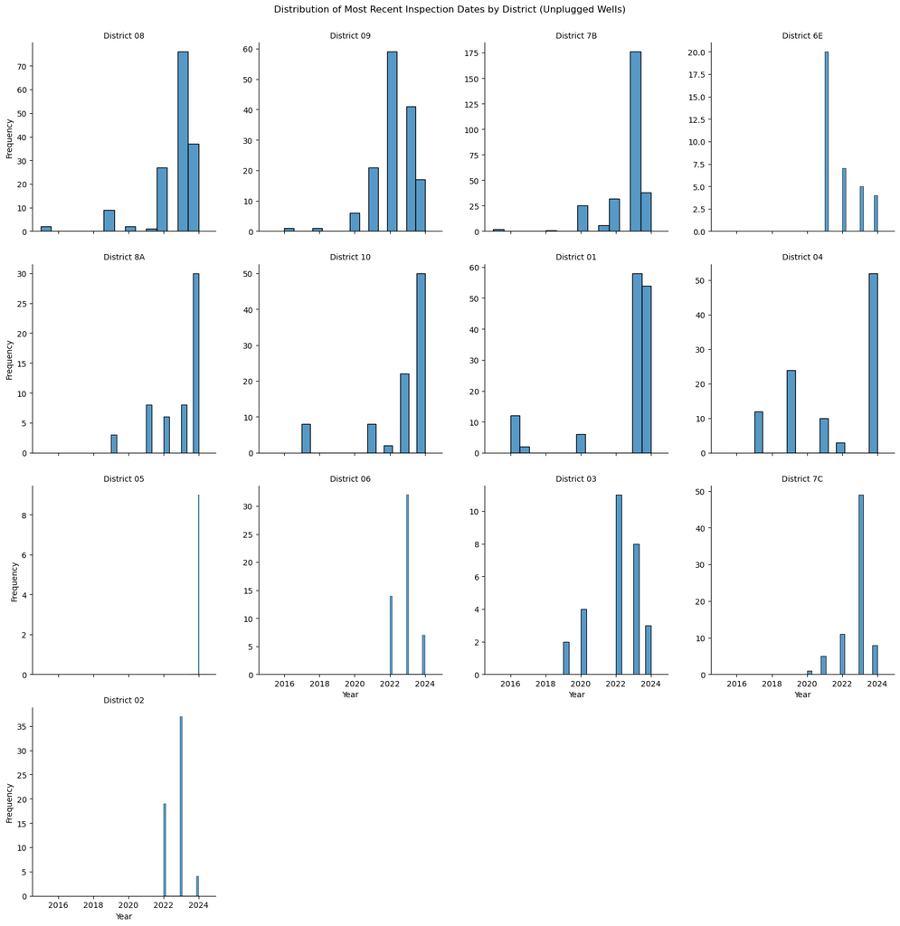

```python
import seaborn as sns
import matplotlib.pyplot as plt

# Facet plot for inspection dates by district
g = sns.FacetGrid(unplugged_wells_with_district, col="district", col_wrap=4, height=4, sharey=False)
g.map_dataframe(sns.histplot, x="inspection_year", bins=15)
g.set_titles(col_template="District {col_name}")
g.set_axis_labels("Year", "Frequency")
g.fig.suptitle('Distribution of Most Recent Inspection Dates by District (Unplugged Wells)', y=1.02)
plt.show()
```

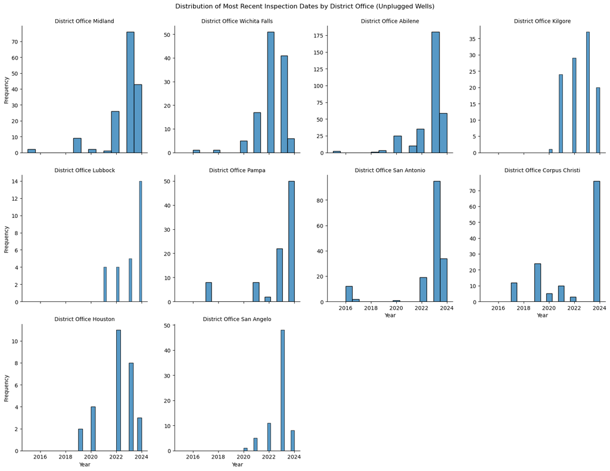

```python
# Facet plot for inspection dates by district office
g = sns.FacetGrid(unplugged_wells_with_district, col="district_office_inspecting", col_wrap=4, height=4, sharey=False)
g.map_dataframe(sns.histplot, x="inspection_year", bins=15)
g.set_titles(col_template="District Office {col_name}")
g.set_axis_labels("Year", "Frequency")
g.fig.suptitle('Distribution of Most Recent Inspection Dates by District Office (Unplugged Wells)', y=1.02)
plt.show()
```

```python
# Check for missing or invalid violation dates
print(unplugged_wells_with_district['violation_year'].isna().sum())
print(unplugged_wells_with_district['violation_year'].describe())

# Filter out rows with invalid violation dates (e.g., years far in the past or future)
valid_violation_years = unplugged_wells_with_district[unplugged_wells_with_district['violation_year'] > 1900]

# Confirm the changes
print(valid_violation_years['violation_year'].describe())
```

```
8959
count     526.000000
mean     2021.539924
std         1.725253
min      2016.000000
25%      2021.000000
50%      2022.000000
75%      2023.000000
max      2024.000000
Name: violation_year, dtype: float64
count     526.000000
mean     2021.539924
std         1.725253
min      2016.000000
25%      2021.000000
50%      2022.000000
75%      2023.000000
max      2024.000000
Name: violation_year, dtype: float64
```

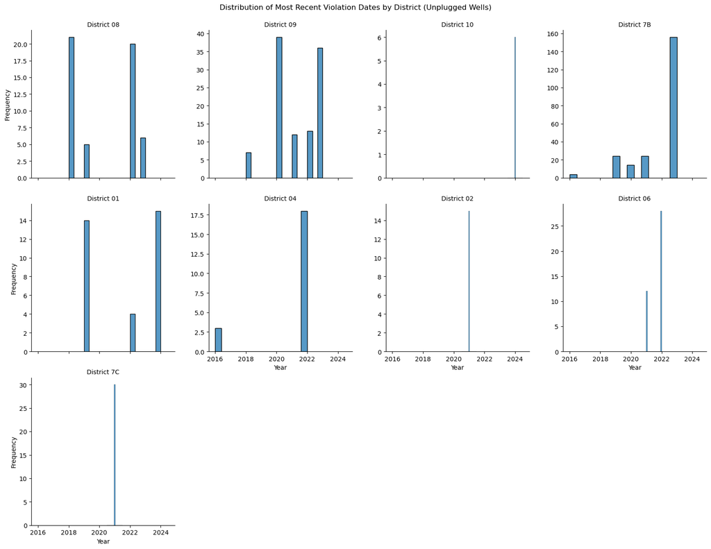

```python
# Facet plot for violation dates by district after cleaning
g = sns.FacetGrid(valid_violation_years, col="district", col_wrap=4, height=4, sharey=False)
g.map_dataframe(sns.histplot, x="violation_year", bins=15)
g.set_titles(col_template="District {col_name}")
g.set_axis_labels("Year", "Frequency")
g.fig.suptitle('Distribution of Most Recent Violation Dates by District (Unplugged Wells)', y=1.02)
plt.show()
```

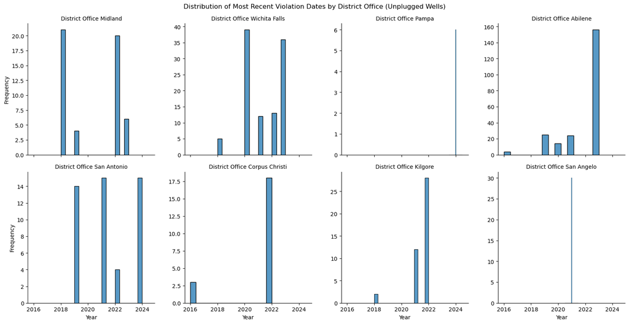

```python
# Facet plot for violation dates by district office after cleaning
g = sns.FacetGrid(valid_violation_years, col="district_office_inspecting", col_wrap=4, height=4, sharey=False)
g.map_dataframe(sns.histplot, x="violation_year", bins=15)
g.set_titles(col_template="District Office {col_name}")
g.set_axis_labels("Year", "Frequency")
g.fig.suptitle('Distribution of Most Recent Violation Dates by District Office (Unplugged Wells)', y=1.02)
plt.show()
```